# D2SC: Weekly Assignments

Jennifer Curi

2024-11-02

# Week 1

I used Google to figure out how to load the tidyverse library. Specifically “How to add a code chunk that loads the tidy verse library”.From there, I made sure to to use different credible websites to ensure that I find the correct code. The first website I opened was Stack Overflow (https://stackoverflow.com/questions/58289197/how-to-write-an-r-chunk-to-load-the-tidyverse).

However, I noticed that the comments were asking the user to clarify his question (i.e R Setup, or R Notebook, R Markdown). From this I employed another search clarifying that I am using R Notebook. From there I looked at another Stack Overflow forum (https://stackoverflow.com/questions/58568048/tidy-verse-issue) and I also looked at the Tidyverse documentation (https://tidyverse.tidyverse.org/) on how to use the library.

To check that it was working, I ran the code and compared my Console output to the Tidyverse documentation output (https://tidyverse.tidyverse.org/). To double check, I also saved the file and looked at the .nbhtml version. I was able to get a condensed summary of conflicts with other packages

```r
# Running Help function to access information about a package
help(package="tidyverse")
```

Package: tidyverse Title: Easily Install and Load the ‘Tidyverse’ Version: 2.0.0 Authors@R: c( person(“Hadley”, “Wickham”, , “hadley@rstudio.com”, role = c(“aut”, “cre”)), person(“RStudio”, role = c(“cph”, “fnd”)) ) Description: The ‘tidyverse’ is a set of packages that work in harmony because they share common data representations and ‘API’ design. This package is designed to make it easy to install and load multiple ‘tidyverse’ packages in a single step. Learn more about the ‘tidyverse’ at https://www.tidyverse.org. License: MIT + file LICENSE URL: https://tidyverse.tidyverse.org, https://github.com/tidyverse/tidyverse BugReports: https://github.com/tidyverse/tidyverse/issues Depends: R (>= 3.3) Imports: broom (>= 1.0.3), conflicted (>= 1.2.0), cli (>= 3.6.0), dbplyr (>= 2.3.0), dplyr (>= 1.1.0), dtplyr (>= 1.2.2), forcats (>= 1.0.0), ggplot2 (>= 3.4.1), googledrive (>= 2.0.0), googlesheets4 (>= 1.0.1), haven (>= 2.5.1), hms (>= 1.1.2), httr (>= 1.4.4), jsonlite (>= 1.8.4), lubridate (>= 1.9.2), magrittr (>= 2.0.3), modelr (>= 0.1.10), pillar (>= 1.8.1), purrr (>= 1.0.1), ragg (>= 1.2.5), readr (>= 2.1.4), readxl (>= 1.4.2), reprex (>= 2.0.2), rlang (>= 1.0.6), rstudioapi (>= 0.14), rvest (>= 1.0.3), stringr (>= 1.5.0), tibble (>= 3.1.8), tidyr (>= 1.3.0), xml2 (>= 1.3.3) Suggests: covr (>= 3.6.1), feather (>= 0.3.5), glue (>= 1.6.2), mockr (>= 0.2.0), knitr (>= 1.41), rmarkdown (>= 2.20), testthat (>= 3.1.6) VignetteBuilder: knitr Config/Needs/website: tidyverse/tidytemplate Config/testthat/edition: 3 Encoding: UTF-8 RoxygenNote: 7.2.3 NeedsCompilation: no Packaged: 2023-02-21 13:20:46 UTC; hadleywickham Author: Hadley Wickham [aut, cre], RStudio [cph, fnd] Maintainer: Hadley Wickham hadley@rstudio.com Repository: CRAN Date/Publication: 2023-02-22 09:20:06 UTC Built: R 4.3.0; ; 2023-07-10 04:39:22 UTC; unix

# Assignment 2

```r
MFIndD_analogy_read <- read_csv("/Users/jencuri/Documents/GitHub/Data2SciComm/WeeklyAssignments/tidy_data/MFIndD_analogy.csv")
```

1. The column qualtrics_id contains the unique identifier for each participant.

```r
?(MFIndD_analogy_read)
```

```r
glimpse(MFIndD_analogy_read)
```

```
## Rows: 792
## Columns: 6
## $ qualtrics_id  <chr> "R_2dlRKzx851f1Yd9", "R_2dlRKzx851f1Yd9", "R_2dlRKzx851f…
## $ trial_number  <dbl> 3, 4, 1, 6, 5, 8, 2, 7, 7, 1, 6, 2, 4, 8, 5, 3, 8, 6, 3,…
## $ match_type_0  <chr> "Rel", "Rel", "Rel", "Obj", "Obj", "Obj", "Rel", "Obj", …
## $ match_type_1  <chr> "Obj", "Obj", "Obj", "Rel", "Rel", "Rel", "Obj", "Rel", …
## $ response      <dbl> 1, 1, 1, 0, 0, 0, 1, 0, 0, 1, 0, 1, 1, 0, 0, 1, 0, 1, 0,…
## $ response_type <chr> "Obj", "Obj", "Obj", "Obj", "Obj", "Obj", "Obj", "Obj", …
```

2a. There are 792 rows in the dataset. There are 6 columns in the data set. I got this by using the ? function. Then I used the glimpse function to get the information. I verified by opening the csv file on excel to see the number of rows and numbers of columns.

```r
MFIndD_analogy_read %>%
  distinct(qualtrics_id) %>%
  glimpse()
```

```
## Rows: 99
## Columns: 1
## $ qualtrics_id <chr> "R_2dlRKzx851f1Yd9", "R_Qb1tzaskoeU0kLf", "R_8AGSWBQpPasv…
```

```r
MFIndD_analogy_read %>%
   count(qualtrics_id)
```

| qualtrics_id | n |
| --- | --- |
| R_0SrX3uRtXaupbhv | 8 |
| R_0V8O8mrLiHO3Ghj | 8 |
| R_1BW5H5J1jQFEpuk | 8 |
| R_1E0SHQwiV6CXRoo | 8 |
| R_1F9e3CRe4Tb8JhE | 8 |
| R_1GPuj1DFOUqlnm3 | 8 |
| R_1HhiPBhEZlHHZjR | 8 |
| R_1OE4UYt6m2Rizjh | 8 |
| R_1ONTbHt5TJisuds | 8 |
| R_1Tv8RlXGXRDH6BX | 8 |

[output cut: 89 more lines]

```r
#Used to Verify
```

2b. There are 99 people in the dataset.

```r
MFIndD_analogy_read %>%
  group_by(qualtrics_id) %>%
  summarise(num_of_trials = length(trial_number))
```

| qualtrics_id | num_of_trials |
| --- | --- |
| R_0SrX3uRtXaupbhv | 8 |
| R_0V8O8mrLiHO3Ghj | 8 |
| R_1BW5H5J1jQFEpuk | 8 |
| R_1E0SHQwiV6CXRoo | 8 |
| R_1F9e3CRe4Tb8JhE | 8 |
| R_1GPuj1DFOUqlnm3 | 8 |
| R_1HhiPBhEZlHHZjR | 8 |
| R_1OE4UYt6m2Rizjh | 8 |
| R_1ONTbHt5TJisuds | 8 |
| R_1Tv8RlXGXRDH6BX | 8 |

[output cut: 89 more lines]

2c. Yes, everyone has data from the same number of trials.

# Assignment 3

```r
MFIndD_analogy_read %>%
  ungroup()
```

| qualtrics_id | trial_number | match_type_0 | match_type_1 | response | response_type |
| --- | --- | --- | --- | --- | --- |
| R_2dlRKzx851f1Yd9 | 3 | Rel | Obj | 1 | Obj |
| R_2dlRKzx851f1Yd9 | 4 | Rel | Obj | 1 | Obj |
| R_2dlRKzx851f1Yd9 | 1 | Rel | Obj | 1 | Obj |
| R_2dlRKzx851f1Yd9 | 6 | Obj | Rel | 0 | Obj |
| R_2dlRKzx851f1Yd9 | 5 | Obj | Rel | 0 | Obj |
| R_2dlRKzx851f1Yd9 | 8 | Obj | Rel | 0 | Obj |
| R_2dlRKzx851f1Yd9 | 2 | Rel | Obj | 1 | Obj |
| R_2dlRKzx851f1Yd9 | 7 | Obj | Rel | 0 | Obj |
| R_Qb1tzaskoeU0kLf | 7 | Obj | Rel | 0 | Obj |
| R_Qb1tzaskoeU0kLf | 1 | Rel | Obj | 1 | Obj |

[output cut: 782 more lines]

```r
summary_MFIndD_analogy <- MFIndD_analogy_read %>%
  group_by(qualtrics_id) %>%
  summarise(num_rel_matches = sum(response_type == "Rel"))
```

```r
(summary_MFIndD_analogy)
```

| qualtrics_id | num_rel_matches |
| --- | --- |
| R_0SrX3uRtXaupbhv | 0 |
| R_0V8O8mrLiHO3Ghj | 8 |
| R_1BW5H5J1jQFEpuk | 8 |
| R_1E0SHQwiV6CXRoo | 4 |
| R_1F9e3CRe4Tb8JhE | 2 |
| R_1GPuj1DFOUqlnm3 | 0 |
| R_1HhiPBhEZlHHZjR | 8 |
| R_1OE4UYt6m2Rizjh | 6 |
| R_1ONTbHt5TJisuds | 8 |
| R_1Tv8RlXGXRDH6BX | 0 |

[output cut: 89 more lines]

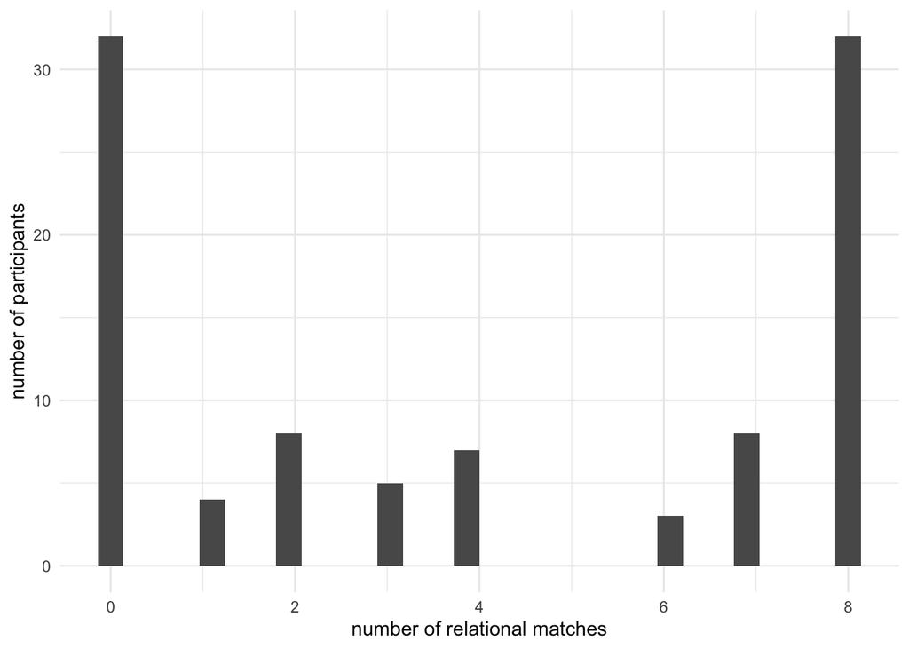

```r
summary_MFIndD_analogy %>%
  ggplot(aes(x = num_rel_matches)) +
  geom_histogram() +
  labs( x = "number of relational matches",
        y = "number of participants") +
  theme_minimal(

  )
```

2. There is a lot of variation in the number of relational matches chosen by participants, no uniformity. It looks like some participants consistently chose relational matches and others picking object matches more often.

```r
MFIndD_analogy_wider <- MFIndD_analogy_read %>%
  pivot_wider(id_cols = qualtrics_id,
              names_from = trial_number,
              values_from = response_type,
              names_sort = TRUE,
              names_prefix = "trial_")
```

```r
(MFIndD_analogy_wider)
```

| qualtrics_id | trial_1 | trial_2 | trial_3 | trial_4 | trial_5 | trial_6 | trial_7 | trial_8 |
| --- | --- | --- | --- | --- | --- | --- | --- | --- |
| R_2dlRKzx851f1Yd9 | Obj | Obj | Obj | Obj | Obj | Obj | Obj | Obj |
| R_Qb1tzaskoeU0kLf | Obj | Obj | Obj | Obj | Obj | Obj | Obj | Obj |
| R_8AGSWBQpPasvjmp | Rel | Rel | Rel | Rel | Rel | Rel | Rel | Obj |
| R_1Tv8RlXGXRDH6BX | Obj | Obj | Obj | Obj | Obj | Obj | Obj | Obj |
| R_3p3Glk1o4y2BcRe | Obj | Obj | Obj | Obj | Obj | Obj | Obj | Rel |
| R_NVYrJklfFqRVOnv | Obj | Obj | Obj | Obj | Obj | Obj | Obj | Obj |
| R_u4J8rwDfOmm4gYV | Obj | Rel | Obj | Rel | Rel | Rel | Obj | Obj |
| R_1lnLF0rQ3biXSbK | Obj | Rel | Rel | Rel | Rel | Rel | Rel | Rel |
| R_3Mm44PUN5bz3OjI | Obj | Obj | Obj | Obj | Obj | Obj | Obj | Obj |
| R_1F9e3CRe4Tb8JhE | Rel | Rel | Obj | Obj | Obj | Obj | Obj | Obj |

[output cut: 89 more lines]

```r
In the beginning, I was struggling with running my code chunk. I then realized that i had to ungroup any groupings I made in the previous assignment in order to start with the orignial data.

I also tried to use count in this code chunk to try to show the numbers of trials for relational matches. But, it was not valid and I used sum instead.
summary_MFIndD_analogy <- MFIndD_analogy_read %>%
  group_by(qualtrics_id) %>%
  summarise(num_rel_matches = count(response_type == "Rel"),
            eval=FALSE)

With the histogram, I tried to add a y column in the aes parameter but it came out as an error, I was then able to use labs to label my axis.
summary_MFIndD_analogy %>%
  ggplot(aes(y = qualtrics_id
    x = num_rel_matches)) +
  geom_histogram() +
  labs( x = "number of relational matches",
        y = "number of participants") +
  theme_minimal(

  ),  eval=FALSE
```

# Assignment 4

```r
MFIndD_REI_read <- read_csv("/Users/jencuri/Documents/GitHub/Data2SciComm/WeeklyAssignments/tidy_data/MFIndD_REI.csv")
head(MFIndD_REI_read)
```

| qualtrics_id | sub_type | item_number | rev_scoring | response | scored_response |
| --- | --- | --- | --- | --- | --- |
| R_1lnLF0rQ3biXSbK | RE | 1 | neg | 2 | 4 |
| R_1lnLF0rQ3biXSbK | RA | 1 | neg | 4 | 2 |
| R_1lnLF0rQ3biXSbK | RE | 2 | NA | 3 | 3 |
| R_1lnLF0rQ3biXSbK | RA | 2 | neg | 3 | 3 |
| R_1lnLF0rQ3biXSbK | RE | 3 | neg | 2 | 4 |
| R_1lnLF0rQ3biXSbK | RE | 4 | NA | 2 | 2 |

1. The column type of “response” is a character type and the column type for “scored_response” is a numeric (dbl). They are different because chr is assigned when a column contains mixed data types. For example, some values are numeric and some are strings. This classifies as chr. On the other hand, “scored_response” is classified as dbl bc the values are numeric values.

```r
MFIndD_REI_read <- MFIndD_REI_read %>%
  mutate(response_double = case_when(
    response == "Strongly Disagree" ~ 1,
    response == "Strongly Agree" ~ 5,
    TRUE ~ as.double(response)

  ))
MFIndD_REI_read <- MFIndD_REI_read %>%
  mutate(new_scored_response = case_when(
    rev_scoring == "neg" ~ 6 - as.numeric(response_double),
    TRUE ~ as.numeric(response_double)
))
```

```r
head(MFIndD_REI_read)
```

| qualtrics_id | sub_type | item_number | rev_scoring | response | scored_response | response_double | new_scored_response |
| --- | --- | --- | --- | --- | --- | --- | --- |
| R_1lnLF0rQ3biXSbK | RE | 1 | neg | 2 | 4 | 2 | 4 |
| R_1lnLF0rQ3biXSbK | RA | 1 | neg | 4 | 2 | 4 | 2 |
| R_1lnLF0rQ3biXSbK | RE | 2 | NA | 3 | 3 | 3 | 3 |
| R_1lnLF0rQ3biXSbK | RA | 2 | neg | 3 | 3 | 3 | 3 |
| R_1lnLF0rQ3biXSbK | RE | 3 | neg | 2 | 4 | 2 | 4 |
| R_1lnLF0rQ3biXSbK | RE | 4 | NA | 2 | 2 | 2 | 2 |

```r
MFIndD_REI_read %>%
  filter(new_scored_response != scored_response)
```

| qualtrics_id | sub_type | item_number | rev_scoring | response | scored_response | response_double | new_scored_response |
| --- | --- | --- | --- | --- | --- | --- | --- |

# Assignment 5

```r
sum_MFIndD_REI_read <- MFIndD_REI_read %>%
  group_by(qualtrics_id, sub_type) %>%
  summarize(score = sum(new_scored_response))
```

Null Values

```r
sum_MFIndD_REI_read <- MFIndD_REI_read %>%
  group_by(qualtrics_id, sub_type) %>%
  summarize(score = sum(new_scored_response, na.rm = TRUE))
head(sum_MFIndD_REI_read)
```

| qualtrics_id | sub_type | score |
| --- | --- | --- |
| R_0SrX3uRtXaupbhv | EA | 31 |
| R_0SrX3uRtXaupbhv | EE | 25 |
| R_0SrX3uRtXaupbhv | RA | 38 |
| R_0SrX3uRtXaupbhv | RE | 37 |
| R_0V8O8mrLiHO3Ghj | EA | 22 |
| R_0V8O8mrLiHO3Ghj | EE | 22 |

```r
is.na(sum_MFIndD_REI_read)
```

[output not shown]

[output cut: 386 more lines]

```r
combined_data <- full_join(sum_MFIndD_REI_read, summary_MFIndD_analogy, by = "qualtrics_id")
```

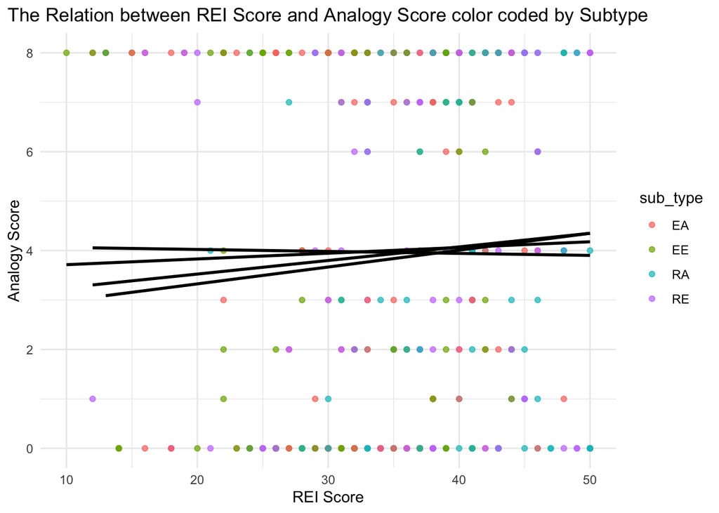

```r
ggplot(combined_data, aes(x = score, y = num_rel_matches, color = sub_type, lines = sub_type)) +
  geom_point(alpha = 0.7) +
  geom_smooth(method = "lm", se = FALSE, color = "black") +
  labs(
    title = "The Relation between REI Score and Analogy Score color coded by Subtype",
    x = "REI Score",
    y = "Analogy Score"
  ) +
  theme_minimal() +
  theme(
    plot.title = element_text(hjust = 0.5)  # Center align the title
  )
```

Observations: 1. The subtypes are evenly distributed across both axes. No concentration of some sort. 2. The trend lines meet seem to cross paths near the 40 mark.

# Assignment 6

```r
MFIndD_probtask_read <-read.csv("/Users/jencuri/Documents/GitHub/Data2SciComm/WeeklyAssignments/tidy_data/MFIndD_probtask.csv")
```

```r
head(MFIndD_probtask_read)
```

|  | SubID | condition | discreteness | regularity | integration | major_color | rt_toolong | rt_tooshort | rt_exclu | shape | details | trial_index | block | left_stim | right_stim | left_path | right_path | rt | response | correct |
| --- | --- | --- | --- | --- | --- | --- | --- | --- | --- | --- | --- | --- | --- | --- | --- | --- | --- | --- | --- | --- |
| 1 | R_2dlRKzx851f1Yd9 | dots_EqSizeSep | discrete | irregular | separated | blue | 0 | 0 | 0 | dots | EqSizeSep | 5 | 0 | 11_3 | 2_18 | StimFiles/dots_EqSizeSep_blue_11_3.jpeg | StimFiles/dots_EqSizeSep_blue_2_18.jpeg | 3952 | arrowleft | TRUE |
| 2 | R_2dlRKzx851f1Yd9 | dots_EqSizeSep | discrete | irregular | separated | blue | 0 | 0 | 0 | dots | EqSizeSep | 8 | 0 | 2_38 | 46_4 | StimFiles/dots_EqSizeSep_blue_2_38.jpeg | StimFiles/dots_EqSizeSep_blue_46_4.jpeg | 2708 | arrowright | TRUE |
| 3 | R_2dlRKzx851f1Yd9 | dots_EqSizeSep | discrete | irregular | separated | blue | 0 | 0 | 0 | dots | EqSizeSep | 11 | 0 | 3_11 | 18_2 | StimFiles/dots_EqSizeSep_blue_3_11.jpeg | StimFiles/dots_EqSizeSep_blue_18_2.jpeg | 2572 | arrowright | TRUE |
| 4 | R_2dlRKzx851f1Yd9 | dots_EqSizeSep | discrete | irregular | separated | blue | 0 | 0 | 0 | dots | EqSizeSep | 14 | 0 | 38_2 | 3_47 | StimFiles/dots_EqSizeSep_blue_38_2.jpeg | StimFiles/dots_EqSizeSep_blue_3_47.jpeg | 2721 | arrowleft | TRUE |
| 5 | R_2dlRKzx851f1Yd9 | dots_EqSizeSep | discrete | irregular | separated | blue | 0 | 0 | 0 | dots | EqSizeSep | 17 | 0 | 7_13 | 12_28 | StimFiles/dots_EqSizeSep_blue_7_13.jpeg | StimFiles/dots_EqSizeSep_blue_12_28.jpeg | 2810 | arrowright | FALSE |
| 6 | R_2dlRKzx851f1Yd9 | dots_EqSizeSep | discrete | irregular | separated | blue | 0 | 0 | 0 | dots | EqSizeSep | 20 | 0 | 6_9 | 9_36 | StimFiles/dots_EqSizeSep_blue_6_9.jpeg | StimFiles/dots_EqSizeSep_blue_9_36.jpeg | 2395 | arrowright | FALSE |

```r
MFIndD_probtask_read %>%
  distinct(condition) %>%
  glimpse()
```

```
## Rows: 4
## Columns: 1
## $ condition <chr> "dots_EqSizeSep", "dots_EqSizeRand", "blob_shifted", "blob_s…
```

There are 4 distinct values in the “condition” column.

```r
distinct_condition_values <- c("dots_EqSizeSep","dots_EqSizeRand","blob_shifted","blob_stacked")
print(distinct_condition_values)
```

```
## [1] "dots_EqSizeSep"  "dots_EqSizeRand" "blob_shifted"    "blob_stacked"
```

Pseudocode/Plan/Logic: 1. Vector with distinction condition values: Distinct_condition_values 2. Initialize an empty vector for mean reaction time. This is so that when the loop iterates, it stores the value in this vector. **Learned that I need to set it to the length of distinct_condition_values to avoid any other values 3. Loop a. iterate over each index of distinct_condition_value b. store the mean reaction time for the current condition at i. This makes sure that the mean is in the write place in the new vector. c. select and filter the rows where the condition from the intial table matches with distinct_condition_value d. now that the conditions matched, we can now look at corresponding rt e. Take the mean from the rt e. store in the vector mean_reaction_times

```r
mean_reaction_times <- numeric(length(distinct_condition_values))
```

```r
for (i in seq_along(distinct_condition_values)) {
  mean_reaction_times[i] <- mean(MFIndD_probtask_read$rt[MFIndD_probtask_read$condition == distinct_condition_values[i]])
}
print (mean_reaction_times)
```

```
## [1] 889.8202 879.6184 892.2855 847.5153
```

When I ran this I got “[1] 889.8202 879.6184 892.2855 847.5153 NaN NaN NaN NaN”. When I first initialized mean_reaction_time, I had c() so I can store the values in here. But I realized I had to set it equal to the length of the vector of the distinct columns so there are no other values. I also added the numeric().

```r
accuracy_table_mean_across <- MFIndD_probtask_read %>%
  group_by(condition) %>%
  summarize(
    across(c(rt, correct), mean, na.rm = TRUE)
  )
print(accuracy_table_mean_across)
```

```
## # A tibble: 4 × 3
##   condition          rt correct
##   <chr>           <dbl>   <dbl>
## 1 blob_shifted     892.   0.620
## 2 blob_stacked     848.   0.697
## 3 dots_EqSizeRand  880.   0.687
## 4 dots_EqSizeSep   890.   0.618
```

```r
accuracy_table_mean <- MFIndD_probtask_read %>%
  group_by(condition) %>%
  summarize(
    mean_rt = mean(rt, na.rm = TRUE),
    accuracy = mean(correct, na.rm = TRUE)
  )


print(accuracy_table_mean)
```

```
## # A tibble: 4 × 3
##   condition       mean_rt accuracy
##   <chr>             <dbl>    <dbl>
## 1 blob_shifted       892.    0.620
## 2 blob_stacked       848.    0.697
## 3 dots_EqSizeRand    880.    0.687
## 4 dots_EqSizeSep     890.    0.618
```

# Assignment 7

```r
prob_data <- read_csv("/Users/jencuri/Documents/GitHub/Data2SciComm/WeeklyAssignments/tidy_data/MFIndD_probtask.csv")
```

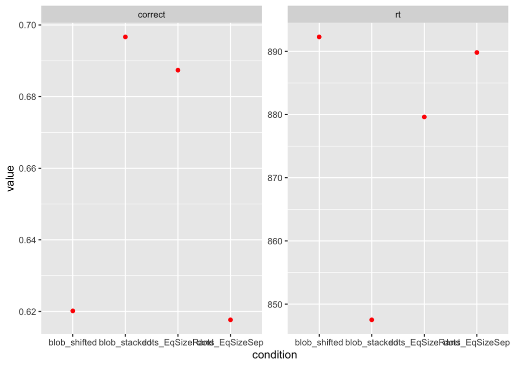

```r
prob_data %>%
group_by(condition) %>%
summarise(across(c(rt, correct), mean)) %>%
pivot_longer(c(rt, correct)) %>%
ggplot(aes(y = value, x = condition)) +
geom_point(color = "red") +
facet_wrap(~name, scales = "free")
```

1a. Interpretations:

Scores: there seems to be slight variation in the people’s scores across the different conditions. It looks like blob_shifted and dots_EqSizeSep show lower accuracy and dots_EqSizeRand and blob_stacked have higher accuracy

rt: it (almost) follows the same shape/patters as the “correct” table but flipped. (blob_shifted and dots_EqSizeSep) have slightly higher reaction times and (dots_EqSizeRand and blob_stacked) have lower reaction times.

overall, it looks like there is a correlation between the two tables. the plots suggests that different conditions can influence score and rt. Participants under certain conditions(blob_stacked) performed slightly better and took the least amount of time then others. In addition the participants that took the had the highest rt had the lowest accuracy scores.

1b. The first thing I noticed was the correlation between peoples score and rt. They (almost) follow the same pattern/shape, but rt is flipped. I also noticed that in the “score” plot, the mean is depicted as one point per condition, which makes me want to believe that those under certain conditions had the same (or close) accuracy score. For example, the score for those under blob_shifted is 0.62. This might make someone believe that those participants achieved (or was very close to) a score of 0.62.

1c. The “correct” plots only shows the average scores for each condition, but it doesn’t show how much the scores varied (like with error bars or confidence intervals). This makes it harder to tell if participants performed similarly or if their results were very different within the same condition.

```r
prob_data_summarized <- MFIndD_probtask_read %>%
  group_by(SubID, condition) %>%
  summarise(prop_corr = sum(correct == 1)/n())
prob_data_summarized
```

| SubID | condition | prop_corr |
| --- | --- | --- |
| R_0SrX3uRtXaupbhv | dots_EqSizeRand | 0.4696970 |
| R_0SrX3uRtXaupbhv | dots_EqSizeSep | 0.6666667 |
| R_0V8O8mrLiHO3Ghj | blob_shifted | 0.4696970 |
| R_0V8O8mrLiHO3Ghj | blob_stacked | 0.7045455 |
| R_1BW5H5J1jQFEpuk | blob_shifted | 0.5303030 |
| R_1BW5H5J1jQFEpuk | blob_stacked | 0.7045455 |
| R_1E0SHQwiV6CXRoo | blob_shifted | 0.5833333 |
| R_1E0SHQwiV6CXRoo | blob_stacked | 0.7121212 |
| R_1F9e3CRe4Tb8JhE | blob_shifted | 0.5454545 |
| R_1F9e3CRe4Tb8JhE | blob_stacked | 0.6136364 |

[output cut: 188 more lines]

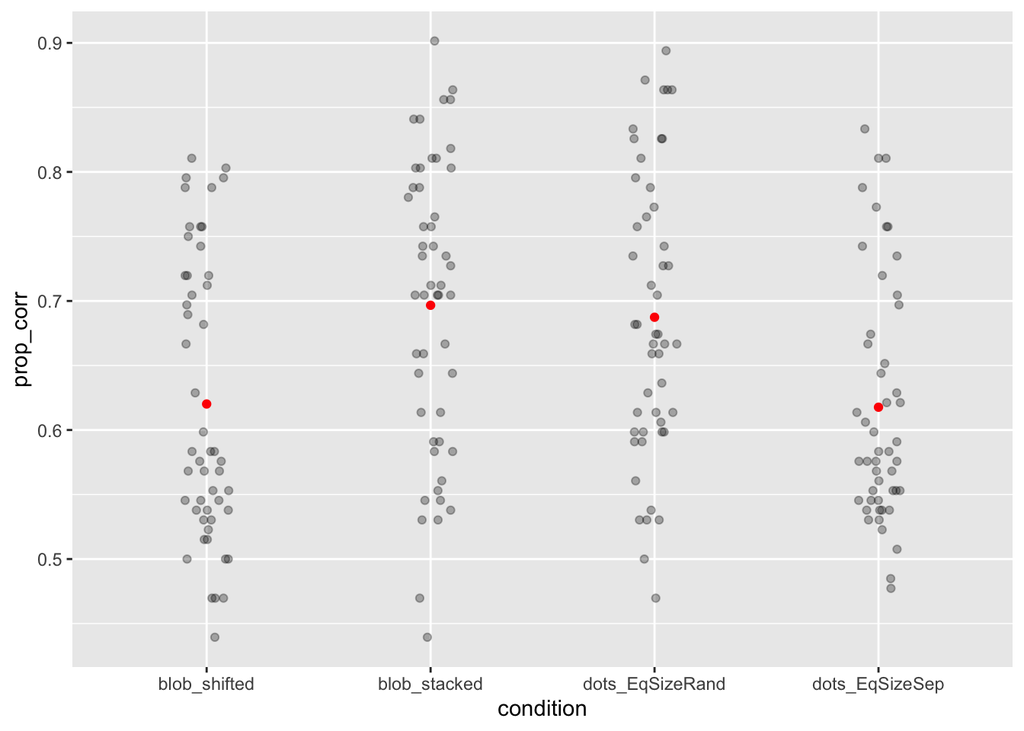

```r
ggplot(prob_data_summarized, aes(x = condition, y = prop_corr)) +
  #stat_summary(fun.data = "mean_se", geom = "errorbar", width = 0.2, color = "red") +
  stat_summary(fun.y = mean, geom = "point", color = "red") +
  geom_jitter(alpha = 0.3, width = 0.1, height = 0)
```

To make the graph less misleading I included the jitter plot so that the distribution of answers is visible.

```r
install.packages("ggdist")
```

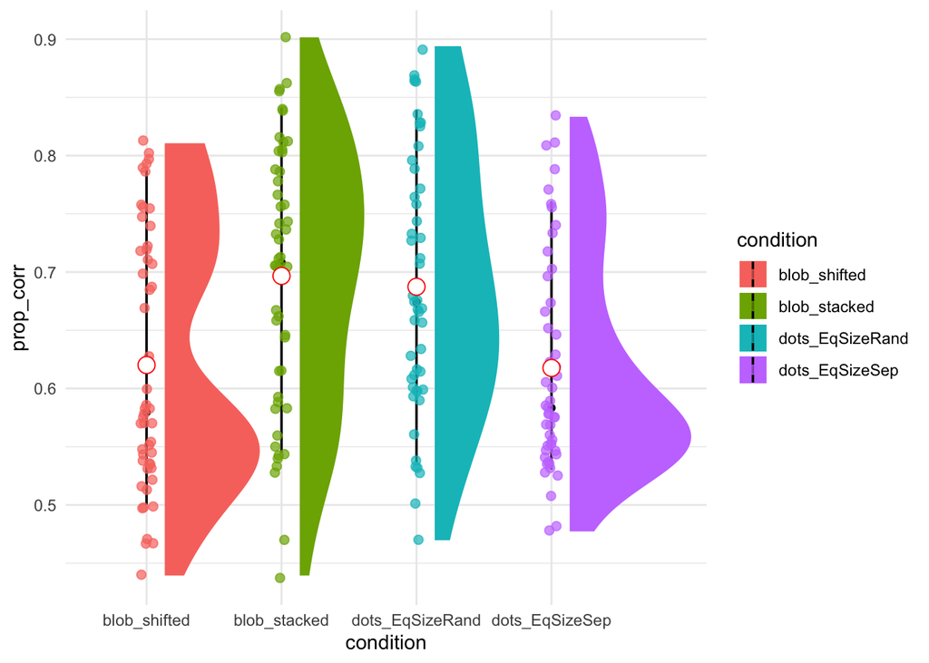

```r
ggplot(prob_data_summarized, aes(x = condition, y = prop_corr)) +
  stat_halfeye(                     #shows density and intervals so that we can speak see the spread of the data.
    aes(fill = condition),
    .width = 0.8,                    # makes data more clear
    justification = -0.15,           # aligns the halfeye with the jitter points
    interval_size = 1.2             # makes interval more clear
  ) +
  geom_jitter(                      # color coded so that its easier to visualize
    aes(color = condition),
    size = 2,
    width = 0.05,
    alpha = 0.7
  ) +
  stat_summary(                     # plot the mean point
    fun.y = mean,
    geom = "point",
    color = "red",
    size = 4,
    shape = 21,
    fill = "white"                  # helps the point stand out more in contrast with the other graph
  )  +

  theme_minimal()                   # my go to theme. makes everything prettier
```

# Assignment 8

```r
prob_data_summary <- prob_data %>%
  group_by(SubID, condition) %>%
  summarise(
    rt = mean(rt, na.rm = TRUE),
    correct = mean(correct, na.rm = TRUE)
  ) %>%
  mutate(
    rt = round(rt,0),
    correct = round(correct, 3)
  )
head(prob_data_summary)
```

| SubID | condition | rt | correct |
| --- | --- | --- | --- |
| R_0SrX3uRtXaupbhv | dots_EqSizeRand | 1030 | 0.470 |
| R_0SrX3uRtXaupbhv | dots_EqSizeSep | 986 | 0.667 |
| R_0V8O8mrLiHO3Ghj | blob_shifted | 742 | 0.470 |
| R_0V8O8mrLiHO3Ghj | blob_stacked | 920 | 0.705 |
| R_1BW5H5J1jQFEpuk | blob_shifted | 824 | 0.530 |
| R_1BW5H5J1jQFEpuk | blob_stacked | 875 | 0.705 |

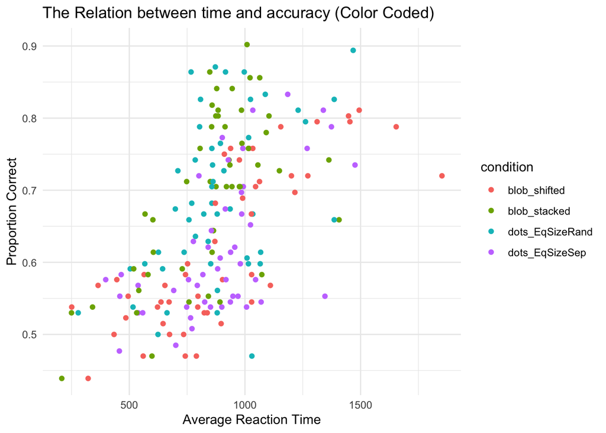

```r
ggplot(prob_data_summary, aes(x = rt, y = correct, color = condition)) +
  geom_point() +
  labs(title = "The Relation between time and accuracy (Color Coded)",
       x = "Average Reaction Time",
       y = "Proportion Correct") +
  theme_minimal()
```

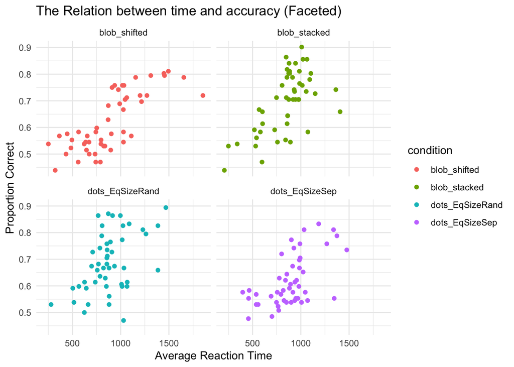

```r
ggplot(prob_data_summary, aes(x = rt, y = correct, color = condition)) +
  geom_point() +
  facet_wrap(~ condition) +
  labs(title = "The Relation between time and accuracy (Faceted)",
       x = "Average Reaction Time",
       y = "Proportion Correct") +
  theme_minimal()
```